# DA 2: Characterizing Multivariate Data

Reesa John

# Part Two: Numerical Summaries and Characterizations

Suppose through the miracle of time travel, you now work at US News and World Report in 1995. You would like to come up with a way to rank all the colleges, based only on the following variables: Average SAT Score, Average ACT Score, Acceptance Rate, Out-of-State Tuition, and Spending per student.

Load and edit the data, if you have not already:

```r
# Read Data
colleges = read.csv('http://kbodwin.web.unc.edu/files/2016/09/tuition_final.csv')

# Adjust labels for later

colleges <- colleges %>% mutate(
  Name = gsub("California State Univ. at", "CSU", Name),
  Name = gsub("California State University at", "CSU", Name),
  Name = gsub("California Polytechnic", "Cal Poly", Name),
  Name = gsub("California Poly", "Cal Poly", Name),
  Name = gsub("University of California at", "UC", Name)
)
```

First, create a data matrix called `Y` which contains only the information we are interested in.

```r
Y <- colleges %>%
  mutate(Accpt.rate = Accepted/Applied )%>%
  select(Avg.SAT,Avg.ACT,Out.Tuition, Accpt.rate, Spending)%>%
  na.omit()

Y <- as.matrix(Y)
dim(Y)
```

```
## [1] 470   5
```

- What is the dimension of `Y`?

```
A 470 x 5 matrix.
```

Next, find the mean and variances of each variable in `Y`, and save them as vectors. You may wish to use the function `apply()` for this task.

```r
means_Y <- apply(Y,2,mean)

vars_Y <- apply(Y,2,var)
```

Now calculate the full covariance matrix of `Y`. Do this in two ways: First, use the function `cov()` to automatically find the matrix. Then, use what you know about matrix multiplication to construct the covariance from scratch. Check that your two answers are the same.

```r
S <- cov(Y)

Ybar = matrix(means_Y,nrow=470,ncol=length(means_Y),byrow=TRUE)

df = 470-1

tempY = Y-Ybar

myCov = (t(tempY)%*%(tempY))*(1/df)

myCov
```

```
##               Avg.SAT  Avg.ACT Out.Tuition Accpt.rate Spending
## Avg.SAT      13992.29  286.261    2.75e+05    -5.9141   343726
## Avg.ACT        286.26    7.123    6.24e+03    -0.1120     7424
## Out.Tuition 275208.90 6238.476    1.55e+07   -96.5730 13139938
## Accpt.rate      -5.91   -0.112   -9.66e+01     0.0196     -228
## Spending    343725.63 7423.957    1.31e+07  -227.5726 24235385
```

```r
S
```

```
##               Avg.SAT  Avg.ACT Out.Tuition Accpt.rate Spending
## Avg.SAT      13992.29  286.261    2.75e+05    -5.9141   343726
## Avg.ACT        286.26    7.123    6.24e+03    -0.1120     7424
## Out.Tuition 275208.90 6238.476    1.55e+07   -96.5730 13139938
## Accpt.rate      -5.91   -0.112   -9.66e+01     0.0196     -228
## Spending    343725.63 7423.957    1.31e+07  -227.5726 24235385
```

You are considering three possible schemes for scoring the schools:

1. *Equal weights*: You will weigh all 5 variables as equally important.
2. *Scores only*: You will only consider the SAT and ACT scores in your ranking.
3. *Complex formula*: 20% SAT Score, 20% ACT Score, 10% Acceptance Rate, 25% Tuition, 25% Spending. (This is approximately the actual weights that US News gives to these variables; however, they also include many more variables that we do not have access to data for.)

Make a matrix `A`, which should have dimension 3 by 5, that contains the weights for the three ranking schemes proposed.

```r
s1 = c(0.2,0.2,0.2,0.2,0.2)
s2 = c(0.5,0.5,0.0,0.0,0.0)
s3 = c(0.2,0.2,0.1,0.25,0.25)

A <- as.matrix(rbind(s1,s2,s3))
```

Note that our variables of interest are on different scales; an average SAT score is around 1000, while an average acceptance rate is around 0.75. To combine these, we want our measurements to be “unitless”. Make a new data matrix where each variable has been standardized by its sample mean and variance. Then calculate the mean vector and covariance matrix for this adjusted data.

```r
sdrow <- sapply(vars_Y,sqrt)

sdrow <- matrix(sdrow,nrow=470,ncol=length(sdrow),byrow=TRUE)

Y_std <- (Y-Ybar)/sdrow

y_bar_std <-  apply(Y_std,2,mean)
S <- cov(Y_std)

y_bar_std
```

```
##     Avg.SAT     Avg.ACT Out.Tuition  Accpt.rate    Spending
##    8.56e-17    1.01e-16   -2.22e-17    9.45e-17    1.73e-16
```

```r
S
```

```
##             Avg.SAT Avg.ACT Out.Tuition Accpt.rate Spending
## Avg.SAT       1.000   0.907       0.591     -0.357    0.590
## Avg.ACT       0.907   1.000       0.594     -0.300    0.565
## Out.Tuition   0.591   0.594       1.000     -0.175    0.678
## Accpt.rate   -0.357  -0.300      -0.175      1.000   -0.330
## Spending      0.590   0.565       0.678     -0.330    1.000
```

- What values are in y-bar? What values are on the diagonal of S? Why do these make sense?

```
I printed out the values of y-bar, which are all essentially 0. The diagonals on S are all 1 because the standard deviation of a standardized variable is 1, and thus the the variance which is square of the standard deviation is also 1. Since we standardized it to have a mean of 0 and a standard deviation of 1, this makes sense.
```

Use an appropriate matrix operation to find the mean score for each of the three ranking schemes.

we have a 3 rows of 470 stuff, and we want 3 means, 1 for each row.

```r
mean_scores <-rowMeans(A%*%t(Y_std))
mean_scores
```

```
##       s1       s2       s3
## 8.69e-17 9.82e-17 1.01e-16
```

Interpret these mean scores.

```
The means of all three variables are essentially 0. This is because they are made from a linear combination of standardized variables with means also practically 0, so naturally their means will also be 0.
```

Use an appropriate matrix operation to find the variances of the three ranking schemes.

```r
rankS <- (A)%*%S%*%t(A)
rankS
```

```
##       s1    s2    s3
## s1 0.421 0.550 0.391
## s2 0.550 0.953 0.503
## s3 0.391 0.503 0.369
```

Use an appropriate matrix operation to find the scores in each of the three schemes for all the colleges in our dataset (except those with missing data). Note that this should be an $n$ by 3 matrix, where columns represent the three scores.

```r
scores <- Y_std%*%t(A)
```

Convert your scores matrix to a matrix of ranks; that is, assign each college a number from 1 to $n$ based on their score, where 1 is the most “desirable” college.

```r
s1 <- rank(-scores[,1],ties.method = "min")
s2 <- rank(-scores[,2],ties.method = "min")
s3 <- rank(-scores[,3],ties.method = "min")

ranks <- colleges %>%
  mutate(Accpt.rate = Accepted/Applied )%>%
  select(Name,Avg.SAT,Avg.ACT,Out.Tuition, Accpt.rate, Spending)%>%
  na.omit()%>%select(Name)

ranks <- cbind(ranks,s1,s2,s3)
```

What are the top 10 ranked colleges for each scheme? Which scheme do you like best, based on this?

This is for scheme 1.

```r
### Make use of this code to find your answers ###
ranks %>%
  filter(s1 <= 10) %>%
  arrange(s1)%>%
  select(Name)
```

```
##                                     Name
## 1               Johns Hopkins University
## 2  Massachusetts Institute of Technology
## 3                     Antioch University
## 4                    Stanford University
## 5             Carnegie Mellon University
## 6                       Emory University
## 7                        Duke University
## 8                           Reed College
## 9                  Vanderbilt University
## 10                        Pomona College
```

```
This is for scheme 2.
```

```r
ranks %>%
  filter(s2 <= 10) %>%
  arrange(s2)%>%
  select(Name)
```

```
##                                     Name
## 1                    Stanford University
## 2  Massachusetts Institute of Technology
## 3                         Pomona College
## 4                        Duke University
## 5               Johns Hopkins University
## 6                    Wesleyan University
## 7             University of Pennsylvania
## 8                Northwestern University
## 9                       Brown University
## 10   Rose-Hulman Institute of Technology
```

```
This is for scheme 3.
```

```r
ranks %>%
  filter(s3 <= 10) %>%
  arrange(s3)%>%
  select(Name)
```

```
##                                     Name
## 1               Johns Hopkins University
## 2                     Antioch University
## 3  Massachusetts Institute of Technology
## 4                    Stanford University
## 5             Carnegie Mellon University
## 6                       Emory University
## 7                  Vanderbilt University
## 8                       Grinnell College
## 9                Northwestern University
## 10            University of Pennsylvania
```

[output not shown]

Where does Cal Poly rank for each scheme?

```r
ranks %>% filter(Name == "Cal Poly-San Luis")
```

```
##                Name  s1  s2  s3
## 1 Cal Poly-San Luis 401 260 416
```

## Your turn

Choose one or more of the ranking schemes. Find an interesting insight into college rankings based on this scheme, by studying the relationship between the ranks and at least one of the variables that we did *not* include in the ranking scheme. Support your observation with plots and numerical summaries.

```r
colleges_2 <- colleges%>%
  mutate(Accpt.rate = Accepted/Applied )%>%
  filter(!is.na(Avg.SAT))%>%
  filter(!is.na(Avg.ACT))%>%
  filter(!is.na(Accpt.rate))%>%
  filter(!is.na(Out.Tuition))%>%
  filter(!is.na(Spending))

colleges_2 <- cbind(colleges_2,s1,s2,s3)

colleges_2 <- colleges_2 %>%
  mutate(
    rank1 = case_when(

      s1 <= 47  ~ "1-47",
      s1 > 47  & s1<= 94 ~ "48-94",
      s1 > 94  & s1<= 141 ~ "95-141",
      s1 > 141 & s1<= 188 ~ "142-188",
      s1 > 188 & s1<= 235 ~ "189-235",
      s1 > 235 & s1<= 282 ~ "236-282",
      s1 > 282 & s1<= 329 ~ "283-329",
      s1 > 329 & s1<= 376 ~ "330-376",
      s1 > 376 & s1<= 423 ~ "377-423",
      TRUE                ~ "424-470"
    ),
    rank2 = case_when(

      s2 <= 47  ~ "1-47",
      s2 > 47  & s2<= 94 ~ "48-94",
      s2 > 94  & s2<= 141 ~ "95-141",
      s2 > 141 & s2<= 188 ~ "142-188",
      s2 > 188 & s2<= 235 ~ "189-235",
      s2 > 235 & s2<= 282 ~ "236-282",
      s2 > 282 & s2<= 329 ~ "283-329",
      s2 > 329 & s2<= 376 ~ "330-376",
      s2 > 376 & s2<= 423 ~ "377-423",
      TRUE                ~ "424-470"
    ),
    rank3 = case_when(

      s3 <= 47  ~ "1-47",
      s3 > 47  & s3<= 94 ~ "48-94",
      s3 > 94  & s3<= 141 ~ "95-141",
      s3 > 141 & s3<= 188 ~ "142-188",
      s3 > 188 & s3<= 235 ~ "189-235",
      s3 > 235 & s3<= 282 ~ "236-282",
      s3 > 282 & s3<= 329 ~ "283-329",
      s3 > 329 & s3<= 376 ~ "330-376",
      s3 > 376 & s3<= 423 ~ "377-423",
      TRUE                ~ "424-470"
    )

  )
```

```
I have chosen to create 10 groupings for each rank based on how high in rank they are for each.
```

```r
colleges_2 %>%
  group_by(rank1)%>%
  na.omit()%>%
  summarize(Applied = mean(Applied))%>%
  arrange(desc(Applied))
```

```
## # A tibble: 10 x 2
##    rank1   Applied
##    <chr>     <dbl>
##  1 1-47      4880.
##  2 142-188   3657.
##  3 377-423   2869
##  4 236-282   2766.
##  5 330-376   2627.
##  6 95-141    2555.
##  7 424-470   2390.
##  8 189-235   2318.
##  9 48-94     1890.
## 10 283-329   1846.
```

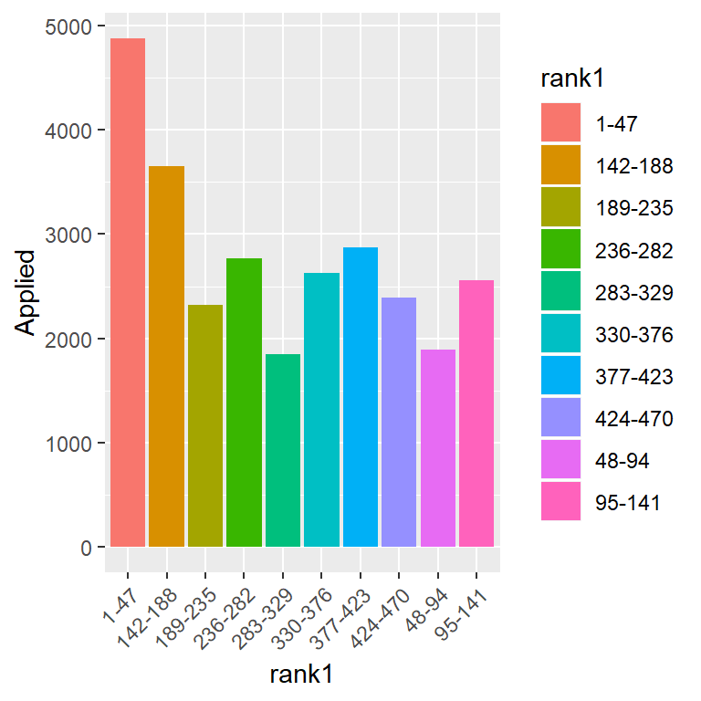

```r
colleges_2 %>%
  group_by(rank1)%>%
  na.omit()%>%
  summarize(Applied = mean(Applied))%>%
  ggplot(aes(x=rank1,y=Applied, fill = rank1))+ geom_col()+
  theme(axis.text.x=element_text(angle=45,hjust=1))
```

```r
colleges_2 %>%
  group_by(rank2)%>%
  na.omit()%>%
  summarize(Applied = mean(Applied))%>%
  arrange(desc(Applied))
```

```
## # A tibble: 10 x 2
##    rank2   Applied
##    <chr>     <dbl>
##  1 1-47      5780.
##  2 189-235   3864.
##  3 142-188   3008.
##  4 48-94     2882.
##  5 95-141    2678.
##  6 236-282   2648.
##  7 330-376   2020.
##  8 377-423   1929.
##  9 424-470   1495.
## 10 283-329   1476.
```

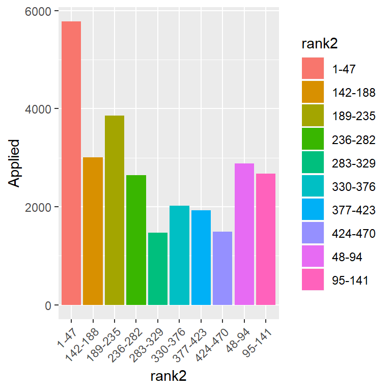

```r
colleges_2 %>%
  group_by(rank2)%>%
  na.omit()%>%
  summarize(Applied = mean(Applied))%>%
  ggplot(aes(x=rank2,y=Applied, fill = rank2))+ geom_col()+
  theme(axis.text.x=element_text(angle=45,hjust=1))
```

```r
colleges_2 %>%
  group_by(rank3)%>%
  na.omit()%>%
  summarize(Applied = mean(Applied))%>%
  arrange(desc(Applied))
```

```
## # A tibble: 10 x 2
##    rank3   Applied
##    <chr>     <dbl>
##  1 1-47      4838.
##  2 142-188   3253.
##  3 236-282   2825.
##  4 377-423   2734.
##  5 95-141    2663.
##  6 330-376   2547.
##  7 424-470   2525.
##  8 48-94     2468.
##  9 189-235   2206.
## 10 283-329   1737.
```

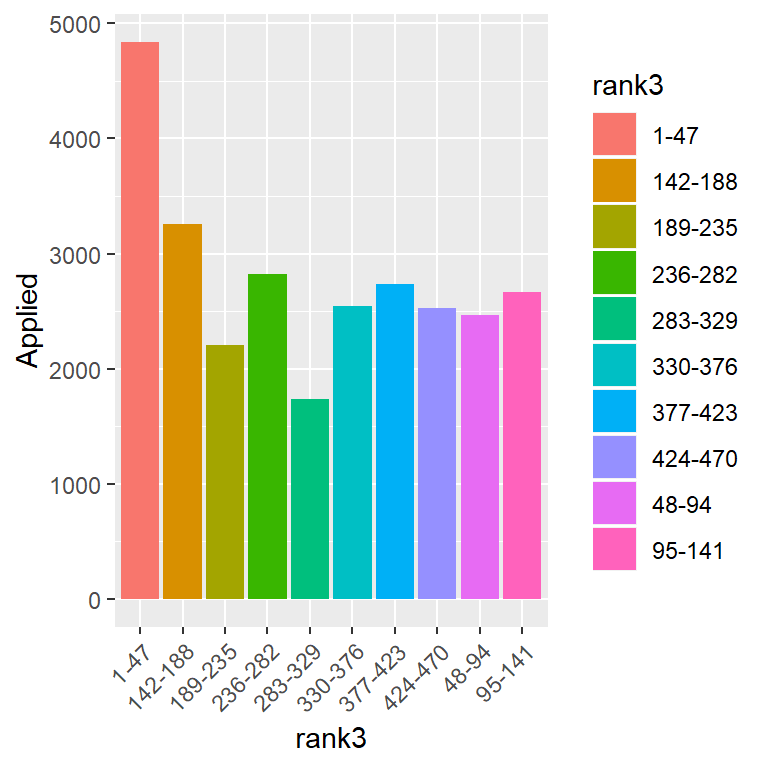

```r
colleges_2 %>%
  group_by(rank3)%>%
  na.omit()%>%
  summarize(Applied = mean(Applied))%>%
  ggplot(aes(x=rank3,y=Applied, fill = rank3))+ geom_col()+
  theme(axis.text.x=element_text(angle=45,hjust=1))
```

`For all three, it is clear from both the numerical summary and the graphs that the mean number of applications for the top 47 in all 3 types of rankings. Suprisingly, the lowest ranked schooles tend to be in the middle of the pack in terms of applications when using ranking types 1 and 3, but when you only consider ACT and SAT scores like in ranking type 2, they are near the bottom. The opposite is true for the top 48-94 schools which tended to be 2nd to last in terms of applications when weighing all factors, but were in the middle of the pack when looking only at standardized test scores.